# Integrating ESG Considerations into Portfolio Optimization

The goal of this project is to demonstrate how Environmental, Social, and Governance (ESG) considerations can be integrated into portfolio optimization. By considering ESG factors alongside traditional financial metrics, investors can create portfolios that are not only financially sound but also socially responsible. This project will showcase the process of integrating ESG scores into portfolio optimization, and analyzing the results to improve investment strategies.

### Utilizing PyPortfolioOpt Library

PyPortfolioOpt is a comprehensive library for portfolio optimization in Python. It provides tools for constructing and optimizing portfolios using various optimization methods. Key features of PyPortfolioOpt include:

- **Efficient Frontier Calculation**: PyPortfolioOpt can compute the efficient frontier, which represents the set of portfolios offering the highest expected return for a given level of risk.
- **Risk Models**: The library supports different risk models, including mean-variance optimization, minimum variance, and maximum Sharpe ratio.
- **Asset Allocation**: PyPortfolioOpt helps in determining the optimal asset allocation based on various constraints and objectives.
- **Performance Evaluation**: It includes functions to evaluate portfolio performance, such as calculating expected returns, volatility, and Sharpe ratios.

In this project, we use PyPortfolioOpt to integrate ESG scores into our portfolio optimization process. The library's flexibility and powerful optimization capabilities make it an ideal choice for this task.

```python
# Uncomment the line below before running
# pip install -U yfinance PyPortfolioOpt
```

```python
#imports
import yfinance as yf
import pandas as pd
import numpy as np
import cvxpy as cp
from pypfopt import expected_returns, risk_models, EfficientFrontier, plotting
from pypfopt.discrete_allocation import DiscreteAllocation, get_latest_prices
import matplotlib.pyplot as plt
from pypfopt.plotting import plot_efficient_frontier
from mpl_toolkits.mplot3d import Axes3D
```

```python
stocks = ["AAPL", "MSFT", "GOOG", "AMZN", "META", "TSLA", "NVDA", "NFLX"]
data = yf.download(stocks, start="2018-01-01", end="2024-01-01")['Adj Close']
```

```
[*********************100%%**********************]  8 of 8 completed
```

```python
data_reset = data.reset_index()
df_numeric = data_reset.drop(columns=['Date'])
df_numeric.head()
```

| Ticker | AAPL | AMZN | GOOG | META | MSFT | NFLX | NVDA | TSLA |
| --- | --- | --- | --- | --- | --- | --- | --- | --- |
| 0 | 40.615894 | 59.450500 | 53.189472 | 181.047943 | 79.936737 | 201.070007 | 4.930643 | 21.368668 |
| 1 | 40.608803 | 60.209999 | 54.062481 | 184.291290 | 80.308739 | 205.050003 | 5.255147 | 21.150000 |
| 2 | 40.797436 | 60.479500 | 54.258255 | 183.951996 | 81.015587 | 205.630005 | 5.282848 | 20.974667 |
| 3 | 41.261929 | 61.457001 | 55.048855 | 186.466827 | 82.020027 | 209.990005 | 5.327617 | 21.105333 |
| 4 | 41.108673 | 62.343498 | 55.284088 | 187.893890 | 82.103714 | 212.050003 | 5.490859 | 22.427334 |

Let's look at an unconstrained portfolio's performance. Our portfolio expects Capital Asset Pricing Model (CAPM) returns, and utilizes semi-covariance method to assess risk.

We can understand how a semicovariance matrix works as a risk model. `PyPortfolioOpt` relies on the concept of mean-variance optimization such that it requires a risk mode for optimization. A simple risk model can just be a sample covariance matrix, which describes asset volatilities and their co-dependence. This is important because one of the principles of diversification is that risk can be reduced by making many uncorrelated bets (correlation is just normalised covariance).

The semivariance is the variance of all returns which are below some benchmark B (typically the risk-free rate) – it is a common measure of downside risk.

```python
mu = expected_returns.capm_return(df_numeric)
S = risk_models.semicovariance(df_numeric, benchmark=((1.0392**(1/252))-1))

ef = EfficientFrontier(mu, S)

raw_weights = ef.max_sharpe()
cleaned_weights = ef.clean_weights()
print(cleaned_weights)
```

```
OrderedDict([('AAPL', 0.1167), ('AMZN', 0.10585), ('GOOG', 0.08325), ('META', 0.08834), ('MSFT', 0.25493), ('NFLX', 0.08199), ('NVDA', 0.15979), ('TSLA', 0.10914)])
```

```python
ef.portfolio_performance(verbose=True)
```

```
Expected annual return: 31.7%
Annual volatility: 23.3%
Sharpe Ratio: 1.27
```

```
(0.317281920998982, 0.23323342242499903, 1.2746111509579165)
```

#### Interpreting the Max Sharpe Ratio

The Sharpe Ratio ( S ) is calculated using the formula:

$S = \frac{R_p - R_f}{\sigma_p}$

Where:

- $R_p$ is the expected portfolio return,
- $R_f$ is the risk-free rate,
- $\sigma_p$ is the standard deviation of the portfolio’s excess returns (a measure of risk).
- **Higher Sharpe Ratio**: Indicates a more attractive risk-adjusted return. A higher Sharpe ratio means the investment is better compensated for the risk taken.
- **Point on Efficient Frontier**: The Max Sharpe Ratio portfolio is often referred to as the Tangency Portfolio because it is tangent to the Capital Allocation Line (CAL) that intersects the risk-free rate.
- **Investment Decision Tool**: Investors use the Max Sharpe Ratio to choose among various portfolios or to adjust their current portfolios towards this optimal point.

We have set the risk-free rate as 0.02 which is a common rate to pick.

## Environmental Social Governance (ESG) Metrics as an Investment Criteria too

**ESG** stands for **Environmental, Social, and Governance**, and it is a set of criteria used to evaluate the potential impact of an investment in these key areas:

- **Environmental** criteria consider how a company performs as a steward of nature. This includes issues like the management of waste, pollution, natural resource conservation, and the treatment of animals. The criteria also evaluate any environmental risks a company might face and how those risks are managed.
- **Social** criteria examine how a company manages relationships with employees, suppliers, customers, and the communities where it operates. This includes considerations of human rights, labor standards in the supply chain, employee relations and diversity, and the company’s impact on the local communities.
- **Governance** criteria focus on a company’s leadership, executive pay, audits, internal controls, and shareholder rights. These criteria help ensure that a company uses accurate and transparent accounting methods, and that shareholders are given the opportunity to vote on important issues.

**ESG investing** is the practice of incorporating these ESG criteria into investment decisions. This approach helps to identify companies with ethical practices that may lead to better long-term financial performance. It reflects a growing belief that these non-financial factors are significant in identifying risks and opportunities, as well as aligning investments with broader social or ethical values.

We aim to incorporate ESG metrics in our portfolio optimization, and are interested in analyzing ESG metrics in the risk and return space.

```python
esg_data = pd.read_csv('SP 500 ESG Risk Ratings.csv')
esg_data.set_index('Symbol', inplace=True)
esg_data = esg_data.dropna(subset=['Total ESG Risk score'])
```

```python
# Arranging ESG scores to be in the same order as the assets in our portfolio
esg_scores = esg_data.loc[df_numeric.columns.intersection(esg_data.index), 'Total ESG Risk score']
```

```python
# Filtering stock prices to include only the stocks for which we have ESG scores
df_numeric_filtered = df_numeric[esg_scores.index]
```

```python
mu1 = expected_returns.capm_return(df_numeric_filtered)
S1 = risk_models.semicovariance(df_numeric_filtered, benchmark=((1.0392**(1/252))-1))
```

```python
# Expected annualised returns of individual stocks (that have ESG scores) in our portfolio
mu1
```

```
Ticker
AAPL    0.264092
AMZN    0.295504
META    0.328801
MSFT    0.261305
NFLX    0.342124
NVDA    0.426163
TSLA    0.451308
Name: mkt, dtype: float64
```

```python
ef_esg = EfficientFrontier(mu1, S1)
```

Here, we set an overall arbitrary ESG target score for our portfolio. This is a case-based score, and can be decided accordingly. An investor or a client can choose a higher score if they are flexible with their ethical values.

**Note:** A higher ESG Risk score of an asset denotes that the asset is worse-off.

```python
# Setting a portfolio ESG risk score target
max_average_esg_score = 20
```

```python
weights = cp.Variable(len(esg_scores))
```

ESG constraints can be applied on two fronts in portfolio optimization:

1. **Pre-Optimization:** Investors can screen stocks based on ESG scores before allocating weights.
2. **During Optimization:** Investors can allocate portfolio weights to stocks based on ESG scores.

We'll look at the latter first.

Here we constraint the weighted ESG risk score of our value to be below or equal to our target score. Intuitively, it means our portfolio will allocate lesser weight to a stock that has a ESG risk score of over 20, and a higher weight to a stock with scores of less than 20.

```python
# The weighted ESG risk scores of the stocks should adhere to the portfolio target
esg_constraint = cp.sum(cp.multiply(esg_scores, weights)) <= max_average_esg_score
```

```python
# Add the ESG constraint
ef_esg.add_constraint(lambda w: esg_constraint)
```

```python
# Continue with optimization
weights = ef_esg.max_sharpe()
cleaned_weights_esg = ef_esg.clean_weights()
print(cleaned_weights_esg)
```

```
OrderedDict([('AAPL', 0.13185), ('AMZN', 0.12218), ('META', 0.09089), ('MSFT', 0.24011), ('NFLX', 0.09995), ('NVDA', 0.18007), ('TSLA', 0.13496)])
```

```python
ef_esg.portfolio_performance(verbose=True)
```

```
Expected annual return: 33.5%
Annual volatility: 24.1%
Sharpe Ratio: 1.31
```

```
(0.3353909521792219, 0.24113256092787572, 1.3079567146203757)
```

Our weighted ESG portfolio has a higher sharpe ratio. That's actually a positive sign in this scenario.

```python
comparison_df = pd.DataFrame({
    'Ticker': list(esg_scores.keys()),
    'Expected Returns': mu1.values,
    'ESG Risk Score': esg_scores.values,
    'Basic Portfolio Weights': [cleaned_weights[ticker] for ticker in esg_scores.keys()],
    'ESG Portfolio Weights': [cleaned_weights_esg[ticker] for ticker in esg_scores.keys()]
})

comparison_df
```

|  | Ticker | Expected Returns | ESG Risk Score | Basic Portfolio Weights | ESG Portfolio Weights |
| --- | --- | --- | --- | --- | --- |
| 0 | AAPL | 0.264092 | 17.0 | 0.11670 | 0.13185 |
| 1 | AMZN | 0.295504 | 30.0 | 0.10585 | 0.12218 |
| 2 | META | 0.328801 | 33.0 | 0.08834 | 0.09089 |
| 3 | MSFT | 0.261305 | 15.0 | 0.25493 | 0.24011 |
| 4 | NFLX | 0.342124 | 16.0 | 0.08199 | 0.09995 |
| 5 | NVDA | 0.426163 | 13.0 | 0.15979 | 0.18007 |
| 6 | TSLA | 0.451308 | 29.0 | 0.10914 | 0.13496 |

`PyPortfolioOpt` does not allow for strict inequalities as constraints. Therefore, the $<=$ on the `max_average_esg_score` seems to be forcing stocks with ESG risk scores of less than 20 but high expected returns (like NVDA) to experience a big jump in allocated weights. But upon observing, all stocks except for MSFT (with the lowest expected return) experience a jump. That goes against our intuition. So, why is that?

We can visualize the efficient frontier of the two portfolios below.

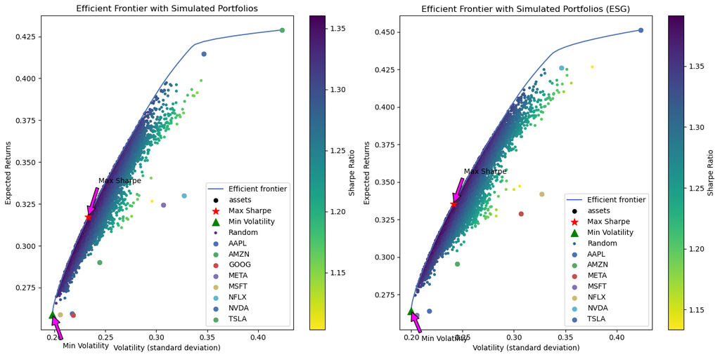

```python
fig, ax = plt.subplots(1, 2, figsize=(14, 7))

# Visualization 1
ef_for_plotting = EfficientFrontier(mu, S)
plotting.plot_efficient_frontier(ef_for_plotting, ax=ax[0], show_assets=True)

ef_max_sharpe = EfficientFrontier(mu, S)
weights = ef_max_sharpe.max_sharpe()
ret_tangent, std_tangent, _ = ef_max_sharpe.portfolio_performance()
ax[0].scatter(std_tangent, ret_tangent, marker="*", s=100, c="r", label="Max Sharpe", zorder=3)

ef_min_vol = EfficientFrontier(mu, S)
weights_min_vol = ef_min_vol.min_volatility()
ret_min_vol, std_min_vol, _ = ef_min_vol.portfolio_performance()
ax[0].scatter(std_min_vol, ret_min_vol, marker="^", s=100, c="g", label="Min Volatility", zorder=3)

# Portfolio Simulations
n_samples = 10000
rand_weights = np.random.dirichlet(alpha=np.ones(ef_for_plotting.n_assets), size=n_samples)
rand_rets = rand_weights.dot(mu)
rand_stds = np.sqrt(np.diag(rand_weights @ S @ rand_weights.T))
sharpes = rand_rets / rand_stds
scatter = ax[0].scatter(rand_stds, rand_rets, c=sharpes, cmap="viridis_r", marker='.', label="Random")

cbar = plt.colorbar(scatter, ax=ax[0])
cbar.set_label("Sharpe Ratio")

for ticker in df_numeric.columns:
    ticker_volatility = np.sqrt(S.loc[ticker, ticker])
    ticker_return = mu[ticker]
    ax[0].scatter(ticker_volatility, ticker_return, marker='o', label=ticker, zorder=2)

ax[0].annotate('Max Sharpe', xy=(std_tangent, ret_tangent), xytext=(std_tangent+0.01, ret_tangent+0.02),
            arrowprops=dict(facecolor='magenta', shrink=0.05))
ax[0].annotate('Min Volatility', xy=(std_min_vol, ret_min_vol), xytext=(std_min_vol+0.01, ret_min_vol-0.02),
            arrowprops=dict(facecolor='magenta', shrink=0.05))

ax[0].set_title("Efficient Frontier with Simulated Portfolios")
ax[0].set_xlabel('Volatility (standard deviation)')
ax[0].set_ylabel('Expected Returns')
ax[0].legend()

# Visualization 2
ef_for_esg = EfficientFrontier(mu1, S1)
plotting.plot_efficient_frontier(ef_for_esg, ax=ax[1], show_assets=True)

ef_max_sharpe = EfficientFrontier(mu1, S1)
weights = ef_max_sharpe.max_sharpe()
ret_tangent, std_tangent, _ = ef_max_sharpe.portfolio_performance()
ax[1].scatter(std_tangent, ret_tangent, marker="*", s=100, c="r", label="Max Sharpe", zorder=3)

ef_min_vol = EfficientFrontier(mu1, S1)
weights_min_vol = ef_min_vol.min_volatility()
ret_min_vol, std_min_vol, _ = ef_min_vol.portfolio_performance()
ax[1].scatter(std_min_vol, ret_min_vol, marker="^", s=100, c="g", label="Min Volatility", zorder=3)

rand_weights = np.random.dirichlet(alpha=np.ones(ef_for_esg.n_assets), size=n_samples)
rand_rets = rand_weights.dot(mu1)
rand_stds = np.sqrt(np.diag(rand_weights @ S1 @ rand_weights.T))
sharpes = rand_rets / rand_stds
scatter = ax[1].scatter(rand_stds, rand_rets, c=sharpes, cmap="viridis_r", marker='.', label="Random")

cbar = plt.colorbar(scatter, ax=ax[1])
cbar.set_label("Sharpe Ratio")

for ticker in df_numeric_filtered.columns:
    ticker_volatility = np.sqrt(S1.loc[ticker, ticker])
    ticker_return = mu1[ticker]
    ax[1].scatter(ticker_volatility, ticker_return, marker='o', label=ticker, zorder=2)

ax[1].annotate('Max Sharpe', xy=(std_tangent, ret_tangent), xytext=(std_tangent+0.01, ret_tangent+0.02),
            arrowprops=dict(facecolor='magenta', shrink=0.05))
ax[1].annotate('Min Volatility', xy=(std_min_vol, ret_min_vol), xytext=(std_min_vol+0.01, ret_min_vol-0.02),
            arrowprops=dict(facecolor='magenta', shrink=0.05))

ax[1].set_title("Efficient Frontier with Simulated Portfolios (ESG)")
ax[1].set_xlabel('Volatility (standard deviation)')
ax[1].set_ylabel('Expected Returns')
ax[1].legend()

plt.tight_layout()
plt.show()
```

## Visualizing an Efficient Surface in the Risk, Return and ESG space

Now let's simulate and visualize portfolios for different ESG target scores.

```python
portfolio_results = []

# Defining a range for the maximum average ESG score
esg_range = np.linspace(10, 70, 100)

for target_esg in esg_range:
    ef = EfficientFrontier(mu1, S1)
    ef.add_constraint(lambda w: cp.sum(cp.multiply(esg_scores, w)) <= target_esg)
    ef.add_constraint(lambda w: cp.sum(cp.multiply(esg_scores, w)) >= (target_esg - 10))

    try:
        ef.max_sharpe()
        performance = ef.portfolio_performance()
        cleaned_weights = ef.clean_weights()
        actual_esg_score = np.dot(list(cleaned_weights.values()), esg_scores)

        portfolio_results.append({
            'Risk': performance[1],
            'Return': performance[0],
            'ESG_Score': actual_esg_score
        })
    except Exception as e:
        print(f"Optimization failed for target ESG score {target_esg} with error: {e}")
```

[output not shown]

[output cut: 17 more lines]

Error messages are for those portfolios that fail to meet the optimization constraint.

```python
portfolios_df = pd.DataFrame(portfolio_results)
portfolios_df.head()
```

|  | Risk | Return | ESG_Score |
| --- | --- | --- | --- |
| 0 | 0.344920 | 0.425314 | 13.03030 |
| 1 | 0.297586 | 0.384172 | 13.63636 |
| 2 | 0.257681 | 0.345084 | 14.24242 |
| 3 | 0.243270 | 0.330734 | 14.84851 |
| 4 | 0.241018 | 0.330426 | 15.45453 |

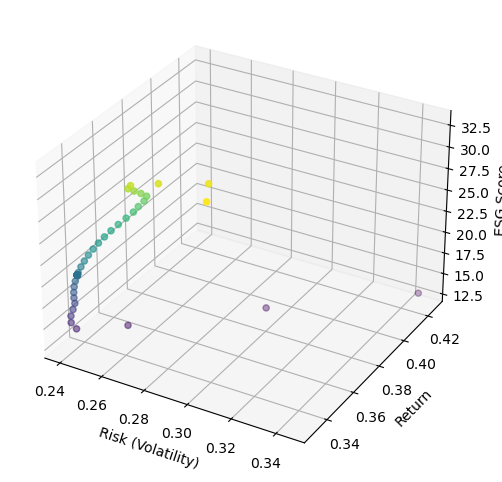

```python
fig = plt.figure(figsize=(10, 6))
ax = fig.add_subplot(111, projection='3d')

ax.scatter(portfolios_df['Risk'], portfolios_df['Return'], portfolios_df['ESG_Score'], c=portfolios_df['ESG_Score'], cmap='viridis')
ax.set_xlabel('Risk (Volatility)')
ax.set_ylabel('Return')
ax.set_zlabel('ESG Score')

plt.show()
```

Here, purple portfolios represent lower ESG scores while yellow portfolios represent higher ESG scores. In our simulation, we can somewhat observe an efficient frontier line that made satisfied the constraints. But we don't observe an efficient surface.

To plot the effience surface, let's simulate portfolios without any constraints. Then we can calculate weighted risk, return and ESG scores of the portfolio simulations that can be plotted in a 3D space.

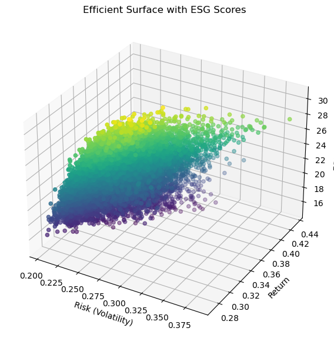

```python
n_samples = 10000
n_assets = len(mu1)

rand_weights = np.random.dirichlet(alpha=np.ones(n_assets), size=n_samples)
mu1 = np.array(mu1)
esg_scores = np.array(esg_scores)

# Monte Carlo Simulations of portfolios
portfolio_returns = np.dot(rand_weights, mu1)
portfolio_risks = np.sqrt(np.einsum('ij,ji->i', rand_weights @ S1, rand_weights.T))
portfolio_esg_scores = np.dot(rand_weights, esg_scores)

portfolios_df = pd.DataFrame({
    'Risk': portfolio_risks,
    'Return': portfolio_returns,
    'ESG_Score': portfolio_esg_scores
})

fig = plt.figure(figsize=(10, 7))
ax = fig.add_subplot(111, projection='3d')

ax.scatter(portfolios_df['Risk'], portfolios_df['Return'], portfolios_df['ESG_Score'],
           c=portfolios_df['ESG_Score'], cmap='viridis', marker='o')
ax.set_xlabel('Risk (Volatility)')
ax.set_ylabel('Return')
ax.set_zlabel('ESG Score')
ax.set_title('Efficient Surface with ESG Scores')

plt.show()
```

Now we can clearly observe an efficient surface in a 3D space.

Here too, purple portfolios represent lower ESG scores while yellow portfolios represent higher ESG scores.

**Analysis:**

Overall, an Effiient Surface allows an investor to further analyse different perspectives on their investment strategies.

## Practical Applications of ESG-Integrated with Portfolio Optimization

1. **Enhanced Portfolio Screening:**
   - Investors can utilize ESG scores to filter out low-performing companies in terms of ESG criteria before performing portfolio optimization. This pre-optimization step ensures that only companies meeting the desired ESG standards are included, enhancing the ethical alignment of the portfolio.
2. **Optimized Weight Allocation:**
   - During the optimization process, ESG scores can be incorporated to adjust the weights of individual assets. Companies with higher ESG scores can be allocated higher weights, while those with lower scores receive less emphasis. This method allows the optimization model to balance financial returns with ESG performance.
3. **Setting ESG Constraints:**
   - Investors can set specific constraints related to ESG performance within the optimization framework. For example, requiring the portfolio to achieve a minimum average ESG score or limiting exposure to industries with high environmental risks. This ensures compliance with ESG standards while optimizing for returns and risk.
4. **Dual Objective Optimization:**
   - The optimization algorithm can be modified to simultaneously optimize for financial returns and ESG performance. This dual objective approach ensures that the portfolio not only seeks to maximize returns but also meets predefined ESG goals, creating a balanced investment strategy. Instead of `PyPortfolioOpt`, we can customize mean-variance optimization algorithms or use integer programming algorithms.
5. **Dynamic Portfolio Rebalancing:**
   - ESG scores can guide the dynamic rebalancing of the portfolio. As ESG scores and financial metrics are updated, the portfolio can be adjusted to maintain alignment with ESG objectives, ensuring continuous adherence to sustainability goals.
6. **Stress Testing with ESG Scenarios:**
   - By incorporating ESG scenarios into stress testing, investors can evaluate how the portfolio performs under various conditions, such as regulatory changes or environmental events. This analysis helps in understanding the portfolio's resilience and adaptability to ESG-related risks.

This project serves as a foundational demonstration of how the above-listed practical applications can be acieved and analyzed.